# Neurological condition analysis

```r
my_packages <- c('tidyverse', 'readxl', 'DT', 'rcartocolor', 'gghighlight',
                 'cowplot', 'broom', 'devtools', 'tableone')

existing_pkgs <- installed.packages()[,"Package"]
to_install <- setdiff(my_packages, existing_pkgs)
if (length(to_install)) install.packages(to_install)
if (!'icd' %in% existing_pkgs) devtools::install_github('jackwasey/icd')

lapply(my_packages, library, character.only = TRUE)
theme_set(theme_bw() +
            theme(legend.title = element_blank(),
                  panel.grid.minor = element_blank()))
for (r_file in list.files('R', full.names = TRUE)) source(r_file)
```

## Data read-in

Change this following chunk of code for your site-specific data:

```r
# set.seed(1)
#mysite = 'penn'
#mask_thres = 10 # count mask threshold
#blur_abs = 0 # absolute max of blurring range
#clin_raw <-
#read_csv(
#  '../thrombotic-penn/data/LocalPatientClinicalCourse.csv',
#  col_types = list(patient_num = col_character())
#)
#demo_raw <-
#read_csv(
#  '../thrombotic-penn/data/LocalPatientSummary.csv',
#  col_types = list(patient_num = col_character()),
#  na = '1900-01-01'
#)
#obs_raw <-
#read_csv(
#  '../thrombotic-penn/data/LocalPatientObservations.csv',
#  col_types = list(patient_num = col_character())
#)
```

```r
mysite = 'nwu'
mask_thres = 0 # count mask threshold
blur_abs = 0 # absolute max of blurring range

clin_raw <- read_csv(
    '../../Phase2.1/Date_Shifted_Files/LocalPatientClinicalCourse_Shift.csv',
    col_types = list(patient_num = col_character()))
demo_raw <- read_csv(
    '../../Phase2.1/Date_Shifted_Files/LocalPatientSummary_Shift.csv',
    col_types = list(patient_num = col_character()),
    na = '1900-01-01')
obs_raw <- read_csv('../../Phase2.1/LocalPatientObservations.csv',
                      col_types = list(patient_num = col_character()))
```

```r
loinc <- read_csv('public-data/loinc-map.csv')
neuro_icds_10 <-
  read_excel('public-data/2020-09-10_neuro-icd10_CNSvPNS.xlsx') %>%
  rename('icd' = `ICD-10`,
         'pns_cns' = `Nervous system Involvement (1=central, 2=peripheral)`) %>%
  mutate(pns_cns = as.factor(pns_cns) %>% fct_recode(central = '1',
                                                     peripheral = '2'))
```

## Data pre-processing

In this initial analysis, we will consider neuro patients as those with a neuro code on the day **of** or **anytime after** their first day of admission. These patients developed neurological conditions after a COVID-19 related admission.

We’re only examining ICD-10 for now.

*Note: comorbidities are estimated with ICD codes recorded from 365-15 days prior to the day of admission.*

```r
neuro_patients <- obs_raw %>%
  filter(
    days_since_admission >= 0,
  ) %>%
  right_join(neuro_icds_10, by = c('concept_code' = 'icd')) %>%
  filter(!is.na(patient_num)) %>%
  distinct(patient_num, concept_code, pns_cns) %>%
  group_by(patient_num) %>%
  mutate(nerv_sys_count = length(unique(pns_cns))) %>%
  ungroup() %>%
  mutate(neuro_type = case_when(
    nerv_sys_count == 2 ~ 'both',
    TRUE ~ as.character(pns_cns)
  ))

patients_pns_cns <- neuro_patients %>%
  distinct(patient_num, neuro_type)

neuro_pt_post <- unique(neuro_patients$patient_num)

non_neuro_patients <- data.frame(
  patient_num = setdiff(demo_raw$patient_num, neuro_pt_post)) %>%
  mutate(concept_code = 'NN')

readmissions <- clin_raw %>%
  group_by(patient_num) %>%
  mutate(delta_hospitalized = diff(c(in_hospital[1], in_hospital))) %>%
  ungroup() %>%
  filter(delta_hospitalized != 0,
         in_hospital == 1) %>%
  add_count(patient_num, name = 'n_readmissions') %>%
  arrange(desc(n_readmissions)) %>%
  select(patient_num, n_readmissions) %>%
  distinct()

nrow(readmissions)
```

```
## [1] 305
```

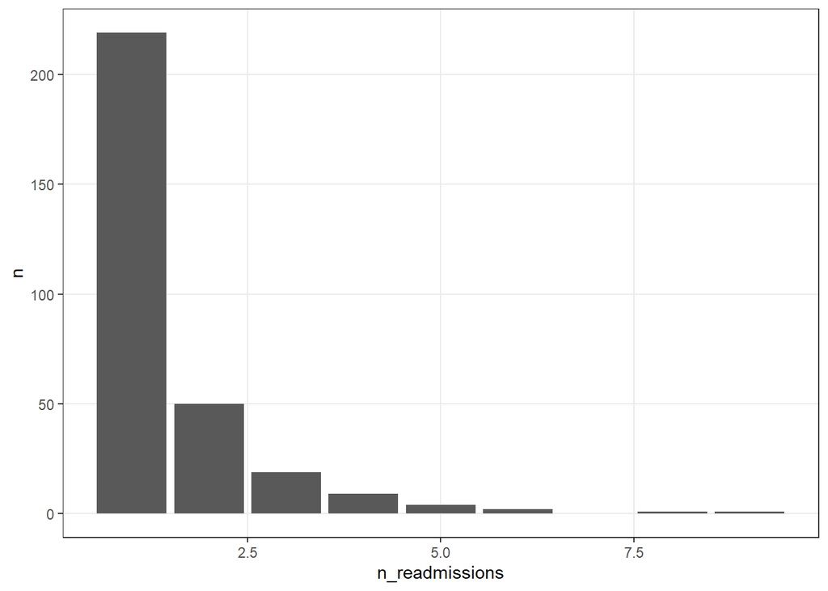

```r
readmissions %>%
  count(n_readmissions) %>%
  blur_it('n', blur_abs, mask_thres) %>%
  ggplot() +
  geom_col(aes(x = n_readmissions, y = n))
```

*Note*: Length of stay is calculated as the period length from admission date to the last discharge date.

```r
days_count_min_max <- obs_raw %>%
  group_by(patient_num) %>%
  summarise(
    distinct_days = n_distinct(days_since_admission),
    min_hos = min(days_since_admission),
    .groups = 'drop'
  )

demo_df <- demo_raw %>%
  mutate(time_to_severe = severe_date - admission_date,
         time_to_severe = ifelse(time_to_severe < 0, NA, time_to_severe),
         time_to_death = death_date - admission_date,
         time_to_death = ifelse(time_to_death < 0, NA, time_to_death),
         readmitted = patient_num %in% readmissions$patient_num,
         Survival = as.factor(deceased) %>%
           fct_recode(Alive = "0", Deceased = "1"),
         sex = as.factor(sex),
         race = as.factor(race),
         age_group = as.factor(age_group),
         Severity = as.factor(severe) %>%
           fct_recode(Severe = "1", `Non-severe` = "0"),
         n_stay = as.numeric(last_discharge_date - admission_date,
                             units="days")) %>%
  left_join(select(neuro_patients, patient_num, neuro_type),
            by = 'patient_num') %>%
  replace_na(list(neuro_type = 'none')) %>%
  mutate(neuro_post = fct_relevel(neuro_type, c('none', 'peripheral', 'central', 'both'))) %>%
  left_join(days_count_min_max, by = 'patient_num')
```

## Demographics (Table 1)

### Overall

```r
vars_to_obfs <- c("sex", 'age_group', "race", "Severity",
                  "Survival", "readmitted")
get_stats <- function(x) demo_stats(demo_df, x, blur_abs, mask_thres)
demo_obfus_table <- lapply(vars_to_obfs, get_stats) %>%
  do.call(rbind, .)
datatable(select(demo_obfus_table, variable, contains('pres')))
```

|  | variable | pres_none | pres_peripheral | pres_central | pres_both |
| --- | --- | --- | --- | --- | --- |
| 1 | sex.female | 1055 (51.1%) | 67 (53.6%) | 341 (45.5%) | 104 (44.8%) |
| 2 | sex.male | 1009 (48.9%) | 58 (46.4%) | 408 (54.5%) | 128 (55.2%) |
| 3 | age_group.00to02 | 7 (0.3%) |  |  |  |
| 4 | age_group.06to11 | 3 (0.1%) |  |  |  |
| 5 | age_group.12to17 | 6 (0.3%) |  |  |  |
| 6 | age_group.18to25 | 103 (5%) | 4 (3.2%) | 15 (2%) | 3 (1.3%) |
| 7 | age_group.26to49 | 673 (32.6%) | 34 (27.2%) | 130 (17.4%) | 43 (18.5%) |
| 8 | age_group.50to69 | 797 (38.6%) | 55 (44%) | 266 (35.5%) | 112 (48.3%) |
| 9 | age_group.70to79 | 260 (12.6%) | 21 (16.8%) | 166 (22.2%) | 36 (15.5%) |
| 10 | age_group.80plus | 215 (10.4%) | 11 (8.8%) | 172 (23%) | 38 (16.4%) |

[output cut: 12 more lines]

### Other descriptive stats

Length of stay, number of readmissions, time to severity onset, time to death

```r
nstay_obfus_table <- nstay_stats(demo_df, blur_abs, mask_thres)
severity_obfus_table <- severity_stats(demo_df, blur_abs, mask_thres)
survival_obfus_table <- survival_stats(demo_df, blur_abs, mask_thres)
readmission_obfus_table <- demo_df %>%
  left_join(readmissions, by = 'patient_num') %>%
  replace_na(list(n_readmissions = 0)) %>%
  readmission_stats(blur_abs, mask_thres)

other_obfus_table <-
  bind_rows(
    nstay_obfus_table,
    readmission_obfus_table,
    severity_obfus_table,
    survival_obfus_table
  )
datatable(other_obfus_table, options = list(pageLength = 12))
```

|  | none | peripheral | central | both |
| --- | --- | --- | --- | --- |
| Median length of stay [Min, Max] (days) | 6 [0, 183] | 10 [1, 183] | 17 [0, 172] | 42 [1, 172] |
| Mean length of stay (SD) (days) | 12 (21) | 27 (41) | 29 (33) | 57 (48) |
| Median number of readmissions [Min, Max] | 0 [0, 9] | 0 [0, 4] | 0 [0, 6] | 0 [0, 8] |
| Mean number of readmissions (SD) | 0 (0) | 0 (1) | 0 (1) | 1 (1) |
| Nonsevere | 1151 (55.8%) | 60 (48%) | 171 (22.8%) | 51 (22%) |
| Severe | 913 (44.2%) | 65 (52%) | 578 (77.2%) | 181 (78%) |
| Median time to severity onset [Min, Max] (days) | 0 [0, 179] | 1 [0, 160] | 0 [0, 188] | 0 [0, 125] |
| Mean time to severity onset (SD) (days) | 8 (23) | 10 (26) | 7 (21) | 11 (25) |
| Alive | 1929 (93.5%) | 123 (98.4%) | 621 (82.9%) | 214 (92.2%) |
| Deceased | 135 (6.5%) | 2 (1.6%) | 128 (17.1%) | 18 (7.8%) |

[output cut: 2 more lines]

## Comorbidity

```r
n_patients <- nrow(demo_raw)
obs_raw <- obs_raw %>%
  filter(concept_type %in% c("DIAG-ICD10", "DIAG-ICD9"))
table(demo_df$neuro_post)
```

```
##
##       none peripheral    central       both
##       2064        125        749        232
```

New variable `neuro_post` to indicate whether the patient developed neurological conditions after COVID-19 related admission.

## Map comorbidities

List of comorbidity abbreviations for reference purposes, then run the `map_char_elix_codes()` function:

```r
# for elixhauser
comorb_names_elix <- get_quan_elix_names()
comorbs_elix <- as.vector(comorb_names_elix$Abbreviation)

# t1: earliest time point to consider comorbidities
# t2: latest time point to consider comorbidities
# example <- t1 = -365, and t2 = -1 will map all all codes up to a year prior but before admission (admission = day 0)

comorb_elix <- map_char_elix_codes(
  df = obs_raw,
  comorb_names = comorb_names_elix,
  t1 = -365,
  t2 = -15,
  map_type = 'elixhauser'
)
```

`map_char_elix_codes()` outputs a 2-element lists:

1- Dataframe of the Charlson/Elixhauser comorbidity index scores

2- Dataframe of the specific mapped codes arranged by frequency. Comorbidity mapping of all patients with ICD codes prior to admission, regardless of whether or not they had a comorbidity.

```r
# elixhauser
index_scores_elix <- comorb_elix$index_scores %>%
  rename('elixhauser_score' = van_walraven_score)
# van Walraven is a modification of Elixhauser comorbidity measure
# doi.org/10.1097/MLR.0b013e31819432e5
mapped_codes_table_elix <- comorb_elix$mapped_codes_table
comorb_names_elix$Abbreviation <- as.character(comorb_names_elix$Abbreviation)
```

Here we can determine how many unique patients we have comorbidity index for prior to admission:

```r
comorb_unique <- select(index_scores_elix, patient_num, elixhauser_score)
length(unique(index_scores_elix$patient_num))
```

```
## [1] 1641
```

## Elixhauser comorbidity matrix

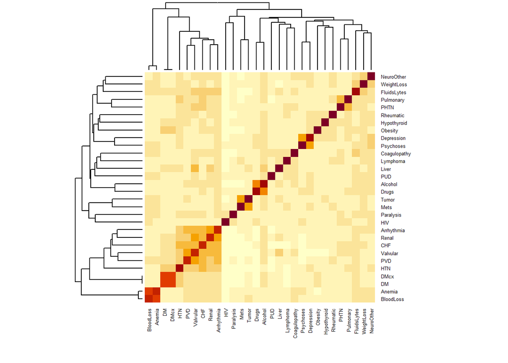

```r
n_comorbs <- colSums(index_scores_elix[, comorbs_elix])
pos_comorbs <- names(n_comorbs[n_comorbs > 0])
elix_mat <- cor(index_scores_elix[, pos_comorbs])
heatmap(elix_mat, cexRow = 0.5, cexCol = 0.5)
```

### Elixhauser Distribution

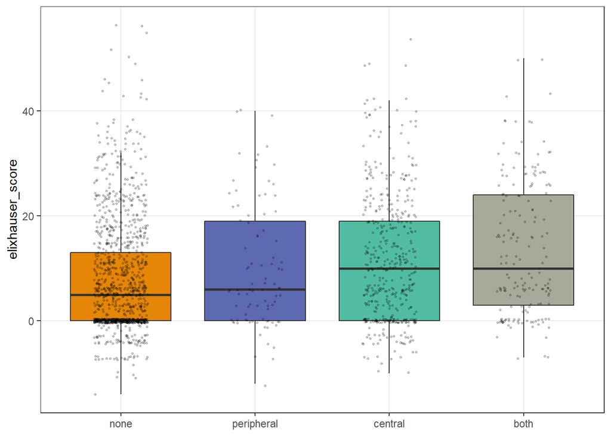

```r
comorb_unique %>%
  left_join(demo_df, by = 'patient_num') %>%
  mutate(severe = as.factor(severe) %>%
           fct_recode('Severe' = '1', 'Non-severe' = '0')) %>%
  ggplot(aes(x = neuro_post, y = elixhauser_score, fill = neuro_post)) +
  geom_boxplot(outlier.colour = NA) +
  geom_jitter(alpha = 0.2, width = 0.2, size = 0.6) +
  guides(fill = FALSE) +
  labs(x = NULL) +
  scale_fill_carto_d()
```

### Elixhauser Comorbidity Table

```r
scores_unique <- left_join(index_scores_elix, demo_df, by = 'patient_num')

scores_neuro <- obs_raw %>%
  # 1 patient can have different code but each only counted once
  distinct(patient_num, concept_code) %>%
  left_join(neuro_icds_10, by = c('concept_code' = 'icd')) %>%
  left_join(scores_unique, by = 'patient_num') %>%
  filter(!is.na(elixhauser_score)) %>%
  mutate(concept_code = case_when(
           is.na(`Neurological Disease Category`) ~ 'NN',
           TRUE ~ concept_code) %>%
           as.factor() %>%
           fct_reorder(- elixhauser_score),
         `Neurological Disease Category` =
           as.factor(`Neurological Disease Category`) %>%
           fct_reorder(elixhauser_score)) %>%
  {.}

elix_obfus_table1 <- get_table1(
  index_scores_elix %>% filter(patient_num %in% neuro_pt_post),
  comorbidities = comorb_names_elix,
  comorbidities_map = comorb_names_elix$Abbreviation) %>%
  rename('n_neuro_pats' = n_patients) %>%
  left_join(get_table1(index_scores_elix,
                       comorbidities_map = comorb_names_elix$Abbreviation,
                       comorbidities = comorb_names_elix),
            by = c("Comorbidity", "Abbreviation")) %>%
  ## apply blurring and masking
  blur_it(c('n_patients', 'n_neuro_pats'), blur_abs, mask_thres) %>%
  mutate(
    n_non_neuro = n_patients - n_neuro_pats,
    prop_patients = n_patients / nrow(demo_raw),
    prop_neuro_pats = n_neuro_pats / nrow(demo_raw),
    prop_non_neuro = n_non_neuro / nrow(demo_raw)
  ) %>%
  arrange(desc(n_neuro_pats))

elix_obfus_table1 %>%
  transmute(
    Comorbidity, Abbreviation,
    neuro_cond = concat(n_neuro_pats, prop_neuro_pats),
    no_neuro_cond = concat(n_non_neuro, prop_non_neuro),
    Total = concat(n_patients, prop_patients)) %>%
  datatable()
```

|  | Comorbidity | Abbreviation | neuro_cond | no_neuro_cond | Total |
| --- | --- | --- | --- | --- | --- |
| 1 | Hypertension, combined | HTN | 241 (8.7%) | 430 (15.5%) | 671 (24.2%) |
| 2 | Other neurological disorders | NeuroOther | 219 (7.9%) | 345 (12.4%) | 564 (20.3%) |
| 3 | Cardiac arrhythmias | Arrhythmia | 176 (6.3%) | 336 (12.1%) | 512 (18.5%) |
| 4 | Diabetes, uncomplicated | DM | 152 (5.5%) | 291 (10.5%) | 443 (16%) |
| 5 | Diabetes, complicated | DMcx | 152 (5.5%) | 291 (10.5%) | 443 (16%) |
| 6 | Renal failure | Renal | 145 (5.2%) | 284 (10.2%) | 429 (15.5%) |
| 7 | Rheumatoid arthritis/collagen vascular diseases | Rheumatic | 144 (5.2%) | 280 (10.1%) | 424 (15.3%) |
| 8 | Congestive heart failure | CHF | 118 (4.3%) | 227 (8.2%) | 345 (12.4%) |
| 9 | Valvular disease | Valvular | 115 (4.1%) | 192 (6.9%) | 307 (11.1%) |
| 10 | Depression | Depression | 104 (3.7%) | 170 (6.1%) | 274 (9.9%) |

[output cut: 20 more lines]

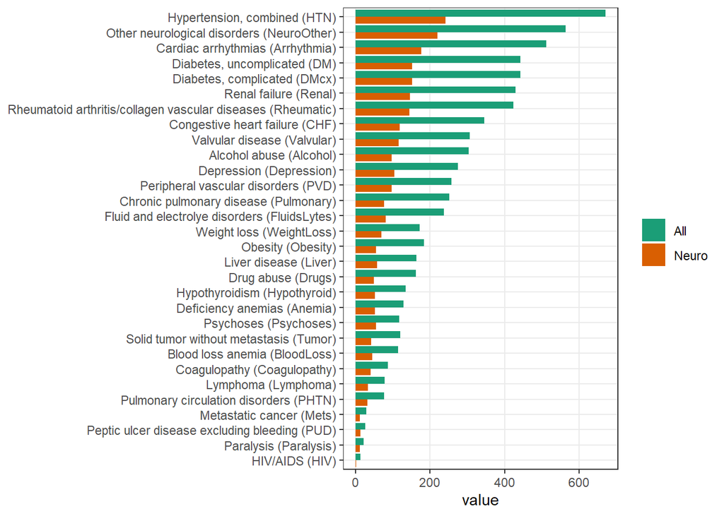

```r
elix_obfus_table1 %>%
  pivot_longer(c(n_patients, n_neuro_pats)) %>%
  mutate(fullname = glue::glue('{Comorbidity} ({Abbreviation})'))%>%
  ggplot(aes(x = value, y = fct_reorder(fullname, value), fill = name)) +
  geom_col(position = 'dodge') +
  scale_fill_brewer(palette = 'Dark2', direction = -1,
                    guide = guide_legend(reverse=TRUE),
                    label = c('Neuro', 'All')) +
  labs(y = NULL)
```

## Short term outcomes

Do hospitalized COVID-19 patients with neurological conditions have a different short-term natural history (hospital days, death, severity, readmission) from those without?

Resolution: Elixhauser score vs comorbidity type, Neurological condition (TRUE/FALSE) vs. neurological ICD code?

### Severity, Death, Length of stay

```r
severe_reg_elix <- glm(severe ~ neuro_post + elixhauser_score + sex + age_group + race,
   data = scores_unique, family = 'binomial') %>%
  tidy()
severe_reg_elix
```

```
## # A tibble: 18 x 5
##    term                          estimate std.error statistic  p.value
##    <chr>                            <dbl>     <dbl>     <dbl>    <dbl>
##  1 (Intercept)                    -1.40     1.41      -0.997  3.19e- 1
##  2 neuro_postperipheral            0.177    0.226      0.782  4.34e- 1
##  3 neuro_postcentral               1.24     0.130      9.52   1.67e-21
##  4 neuro_postboth                  1.18     0.195      6.04   1.53e- 9
##  5 elixhauser_score                0.0204   0.00476    4.27   1.91e- 5
##  6 sexmale                         0.123    0.102      1.21   2.26e- 1
##  7 age_group06to11                 0.0213   1.51       0.0141 9.89e- 1
##  8 age_group12to17               -12.6    237.        -0.0529 9.58e- 1
##  9 age_group18to25                 1.41     0.906      1.56   1.19e- 1
## 10 age_group26to49                 0.637    0.877      0.727  4.67e- 1
## 11 age_group50to69                 0.691    0.876      0.789  4.30e- 1
## 12 age_group70to79                 0.742    0.881      0.842  4.00e- 1
## 13 age_group80plus                 0.187    0.883      0.211  8.33e- 1
## 14 raceasian                       0.797    1.13       0.704  4.81e- 1
## 15 raceblack                       0.673    1.11       0.609  5.43e- 1
## 16 racehawaiian_pacific_islander  -1.26     1.41      -0.892  3.72e- 1
## 17 raceother                       0.757    1.11       0.682  4.95e- 1
## 18 racewhite                       0.338    1.10       0.307  7.59e- 1
```

```r
deceased_reg_elix <- glm(deceased ~ neuro_post + elixhauser_score + sex + age_group + race,
   data = scores_unique, family = 'binomial') %>%
  tidy()
deceased_reg_elix
```

```
## # A tibble: 18 x 5
##    term                          estimate  std.error  statistic   p.value
##    <chr>                            <dbl>      <dbl>      <dbl>     <dbl>
##  1 (Intercept)                   -35.4    4109.      -0.00862   0.993
##  2 neuro_postperipheral          -16.0     645.      -0.0248    0.980
##  3 neuro_postcentral               0.413     0.182    2.27      0.0235
##  4 neuro_postboth                 -0.145     0.305   -0.475     0.635
##  5 elixhauser_score                0.0284    0.00679  4.18      0.0000288
##  6 sexmale                         0.569     0.175    3.24      0.00119
##  7 age_group06to11                -0.0897 4473.      -0.0000200 1.00
##  8 age_group12to17                 0.327  3850.       0.0000849 1.00
##  9 age_group18to25                15.2    2582.       0.00590   0.995
## 10 age_group26to49                14.3    2582.       0.00553   0.996
## 11 age_group50to69                15.8    2582.       0.00611   0.995
## 12 age_group70to79                16.3    2582.       0.00631   0.995
## 13 age_group80plus                16.9    2582.       0.00653   0.995
## 14 raceasian                      16.0    3196.       0.00501   0.996
## 15 raceblack                      16.3    3196.       0.00510   0.996
## 16 racehawaiian_pacific_islander   0.425  3925.       0.000108  1.00
## 17 raceother                      15.3    3196.       0.00479   0.996
## 18 racewhite                      16.6    3196.       0.00520   0.996
```

```r
n_stay_reg_elix <- lm(n_stay ~ neuro_post + elixhauser_score + race + sex + age_group,
   data = scores_unique) %>%
  tidy()

n_stay_reg_elix
```

```
## # A tibble: 18 x 5
##    term                          estimate std.error statistic  p.value
##    <chr>                            <dbl>     <dbl>     <dbl>    <dbl>
##  1 (Intercept)                    -10.7     20.1       -0.532 5.95e- 1
##  2 neuro_postperipheral            15.5      3.43       4.51  6.92e- 6
##  3 neuro_postcentral               14.7      1.78       8.24  3.30e-16
##  4 neuro_postboth                  41.0      2.59      15.8   6.22e-53
##  5 elixhauser_score                 0.492    0.0674     7.29  4.48e-13
##  6 raceasian                       18.5     16.0        1.16  2.47e- 1
##  7 raceblack                       18.2     15.6        1.17  2.42e- 1
##  8 racehawaiian_pacific_islander   34.6     19.4        1.78  7.54e- 2
##  9 raceother                        7.66    15.7        0.489 6.25e- 1
## 10 racewhite                        8.46    15.5        0.544 5.86e- 1
## 11 sexmale                          2.33     1.50       1.56  1.20e- 1
## 12 age_group06to11                  2.31    21.9        0.105 9.16e- 1
## 13 age_group12to17                  7.85    20.0        0.392 6.95e- 1
## 14 age_group18to25                  7.28    13.1        0.554 5.80e- 1
## 15 age_group26to49                  8.97    12.7        0.704 4.82e- 1
## 16 age_group50to69                  8.93    12.7        0.701 4.83e- 1
## 17 age_group70to79                 13.0     12.8        1.01  3.12e- 1
## 18 age_group80plus                  3.10    12.8        0.242 8.09e- 1
```

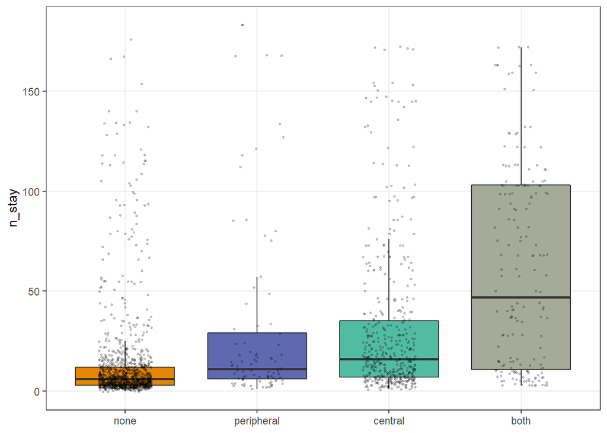

```r
scores_unique %>%
  ggplot(aes(x = neuro_post, y = n_stay, fill = neuro_post)) +
  geom_boxplot(outlier.colour = NA) +
  geom_jitter(alpha = 0.2, width = 0.2, size = 0.6) +
  guides(fill = FALSE) +
  labs(x = NULL) +
  scale_fill_carto_d()
```

**Elixhauser**

```r
nstay_df <- neuro_patients %>%
  bind_rows(non_neuro_patients) %>%
  left_join(demo_df, by = 'patient_num') %>%
  left_join(index_scores_elix, by = 'patient_num') %>%
  # mutate(concept_code = fct_reorder(concept_code, n_stay)) %>%
  left_join(neuro_icds_10, by = c('concept_code' = 'icd')) %>%
  mutate(full_icd = case_when(
    concept_code == 'NN' ~ 'No neurological condition',
    TRUE ~ paste0(`ICD-10 Description`, ' (', concept_code, ')')) %>%
             as.factor() %>% fct_reorder(n_stay))

summarised_obfus_icd <- nstay_df %>%
  group_by(concept_code) %>%
  summarise(mean_stay = mean(n_stay),
            median_stay = median(n_stay),
            sd_stay = sd(n_stay),
            mean_elix = mean(elixhauser_score, na.rm = TRUE),
            median_elix = median(elixhauser_score, na.rm = TRUE),
            sd_elix = sd(elixhauser_score, na.rm = TRUE),
            n_patients = n(),
            prop_deceased = mean(deceased),
            prop_severe = mean(severe),
            .groups = 'drop') %>%
  blur_it('n_patients', blur_abs, mask_thres)
```

```r
list_results = list(
  demo_table = demo_obfus_table,
  other_obfus_table = other_obfus_table,
  elix_obfus_table1 = elix_obfus_table1,
  summarised_obfus_icd = summarised_obfus_icd,
  n_stay_reg_elix = n_stay_reg_elix,
  severe_reg_elix = severe_reg_elix,
  deceased_reg_elix = deceased_reg_elix)

list_results <- lapply(list_results, function(x) mutate(x, site = mysite))
list_results <- c(list_results, elix_mat = elix_mat)

site_results <- paste0(mysite, '_cpns_results')
assign(site_results, list_results)
save(list = site_results,
     file = paste0('results/', mysite, '-cpns-results.rda'))
```